# 01-Data-Analysis

Analysis of accessibility to pharmacies in Hamilton.

Invoke data:

```r
data("data_da_2016")
data("dwelling_network_points_2016")
data("hamilton_cma")
data("modes_55to69")
data("pharmacy_locations")
data("ttm_car")
data("ttm_transit")
data("ttm_walk")
```

## Prepare data

Calculate number of people age 55+ per DA:

```r
data_da_2016 <- data_da_2016 %>%
  filter(`Region Name` == "Hamilton") %>%
  mutate(Population_55to69 = (`v_CA16_208: 55 to 59 years` +
                  `v_CA16_226: 60 to 64 years` +
                  `v_CA16_247: 65 to 69 years`),
         Population_70plus = (`v_CA16_265: 70 to 74 years` +
                  `v_CA16_283: 75 to 79 years` +
                  `v_CA16_301: 80 to 84 years` +
                  `v_CA16_319: 85 years and over`))
```

Select pharmacy locations:

```r
pharmacy_locations <- pharmacy_locations %>%
  slice(1:23)
```

Also filter selected pharmacies from travel time tables:

```r
ttm_car <- ttm_car %>%
  dplyr::filter(OBJECTID <= 23)

ttm_transit <- ttm_transit %>%
  dplyr::filter(OBJECTID <= 23)

ttm_walk <- ttm_walk %>%
  dplyr::filter(OBJECTID <= 23)
```

Clip `data_da_2016`:

```r
data_da_2016 <- data_da_2016 %>%
  st_intersection(hamilton_cma)
```

```
although coordinates are longitude/latitude, st_intersection assumes that they are planar
attribute variables are assumed to be spatially constant throughout all geometries
```

Find number of residential units in each DA:

```r
residential_units <- dwelling_network_points_2016 %>%
  st_drop_geometry() %>%
  group_by(DAUID) %>%
  summarize(residential_units = sum(Dwellings))
```

Join number of people age 55+ per DA to dwellings and total number of residential units:

```r
dwelling_network_points_2016 <- dwelling_network_points_2016 %>%
  left_join(data_da_2016 %>%
              st_drop_geometry() %>%
              dplyr::transmute(DAUID = GeoUID,
                               Population_55to69,
                               Population_70plus),
            by = "DAUID") %>%
  left_join(residential_units,
            by = "DAUID")
```

Calculate population per point on the network. This is the population in the DA divided by the total number of residential units. This gives the average number of people per residential unit. Then, multiply by the number of dwellings (residential units) at the point:

```r
dwelling_network_points_2016 <- dwelling_network_points_2016 %>%
  mutate(Population_55to69 = (Population_55to69/residential_units) * Dwellings,
         Population_70plus = (Population_70plus/residential_units) * Dwellings)
```

Join the population data to the travel time matrices:

```r
ttm_car <- ttm_car %>%
  left_join(dwelling_network_points_2016 %>%
              st_drop_geometry() %>%
              dplyr::select(ID,
                            Population_55to69,
                            Population_70plus,
                            DAUID,
                            TAZUID),
            by = c("UID" = "ID"))

ttm_transit <- ttm_transit %>%
  left_join(dwelling_network_points_2016 %>%
              st_drop_geometry() %>%
              dplyr::select(ID,
                            Population_55to69,
                            Population_70plus,
                            DAUID,
                            TAZUID),
            by = c("UID" = "ID"))

ttm_walk <- ttm_walk %>%
  left_join(dwelling_network_points_2016 %>%
              st_drop_geometry() %>%
              dplyr::select(ID,
                            Population_55to69,
                            Population_70plus,
                            DAUID,
                            TAZUID),
            by = c("UID" = "ID"))
```

Join the pharmacy data to the travel time matrices:

```r
ttm_car <- ttm_car %>%
  left_join(pharmacy_locations %>%
              st_drop_geometry() %>%
              dplyr::select(ID,
                            Type),
            by = c("OBJECTID" = "ID"))

ttm_transit <- ttm_transit %>%
  left_join(pharmacy_locations %>%
              st_drop_geometry() %>%
              dplyr::select(ID,
                            Type),
            by = c("OBJECTID" = "ID"))

ttm_walk <- ttm_walk %>%
  left_join(pharmacy_locations %>%
              st_drop_geometry() %>%
              dplyr::select(ID,
                            Type),
            by = c("OBJECTID" = "ID"))
```

Drop NAs:

```r
ttm_car <- ttm_car %>%
  drop_na(TAZUID,
          Population_55to69)

ttm_transit <- ttm_transit %>%
  drop_na(TAZUID,
          Population_55to69)

ttm_walk <- ttm_walk %>%
  drop_na(TAZUID,
          Population_55to69)
```

Calculate proportion of trips by mode per TAZ:

```r
modes <- modes_55to69 %>%
  mutate(p_car = Driver/(Driver + Transit + Walk),
         p_transit = Transit/(Driver + Transit + Walk),
         p_walk = Walk/(Driver + Transit + Walk))
```

Assume that TAZ with NAs have a proportion of car trips of one:

```r
modes <- modes %>%
  dplyr::mutate(p_car = replace_na(p_car, 1),
                p_transit = replace_na(p_transit, 0),
                p_walk = replace_na(p_walk, 0))
```

Join proportion of trips to table with person-hours

```r
ttm_car <- ttm_car %>%
  left_join(modes %>%
              st_drop_geometry() %>%
              transmute(TAZUID,
                        p_car,
                        p_transit,
                        p_walk),
            by = "TAZUID")

ttm_transit <- ttm_transit %>%
  left_join(modes %>%
              st_drop_geometry() %>%
              transmute(TAZUID,
                        p_car,
                        p_transit,
                        p_walk),
            by = "TAZUID")

ttm_walk <- ttm_walk %>%
  left_join(modes %>%
              st_drop_geometry() %>%
              transmute(TAZUID,
                        p_car,
                        p_transit,
                        p_walk),
            by = "TAZUID")
```

Calculate quintiles of median household income in Hamilton:

```r
mhi_q <- data_da_2016 %>%
  dplyr::filter(`Region Name` == "Hamilton") %>%
  pull(`v_CA16_2397: Median total income of households in 2015 ($)`) %>%
  quantile(c(0, 0.2, 0.4, 0.6, 0.8, 1),
           na.rm = TRUE)
```

Label DAs with income quintiles:

```r
data_da_2016 <- data_da_2016 %>%
  rename(Median_household_income = `v_CA16_2397: Median total income of households in 2015 ($)`) %>%
  mutate(income_quintile = case_when(Median_household_income < mhi_q[2] ~ "Bottom 20%",
                                     Median_household_income >= mhi_q[2] & Median_household_income < mhi_q[3] ~ "Fourth 20%",
                                     Median_household_income >= mhi_q[3] & Median_household_income < mhi_q[4] ~ "Third 20%",
                                     Median_household_income >= mhi_q[4] & Median_household_income < mhi_q[5] ~ "Second 20%",
                                     Median_household_income >= mhi_q[5] ~ "Top 20%"),
         income_quintile = factor(income_quintile,
                                  levels = c("Top 20%",
                                             "Second 20%",
                                             "Third 20%",
                                             "Fourth 20%",
                                             "Bottom 20%"),
                                  ordered = TRUE))
```

## Exploratory data analysis

Summary of population:

```r
sum(data_da_2016$Population_55to69, na.rm = TRUE)
```

```
[1] 103545
```

```r
sum(data_da_2016$Population_70plus, na.rm = TRUE)
```

```
[1] 63635
```

Check the total population:

```r
sum(dwelling_network_points_2016$Population_55to69, na.rm = TRUE)
```

```
[1] 103455
```

```r
sum(dwelling_network_points_2016$Population_70plus, na.rm = TRUE)
```

```
[1] 63020
```

The difference in population is because the residential units considered do not completely cover the Hamilton CMA:

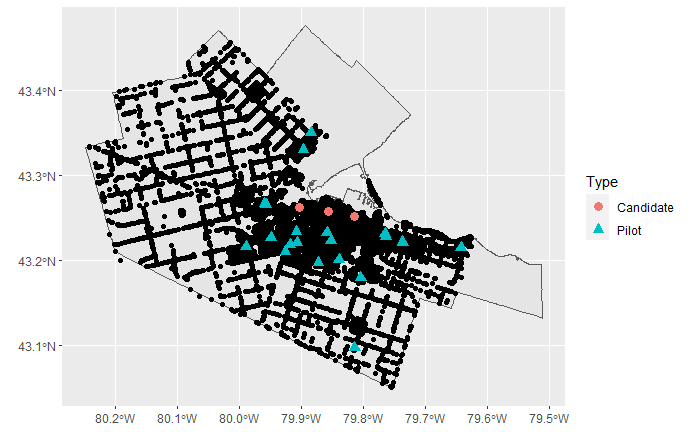

```r
ggplot() +
  geom_sf(data = hamilton_cma) +
  geom_sf(data = dwelling_network_points_2016) +
  geom_sf(data = pharmacy_locations,
          aes(color = Type,
              shape = Type),
          size = 3)
```

Plot population age 55 to 69:

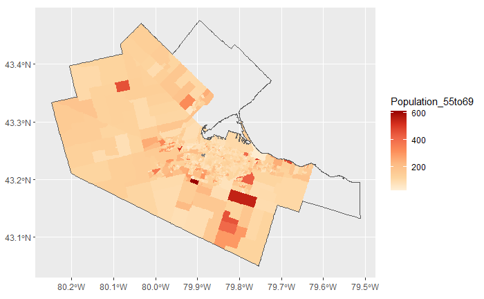

```r
ggplot() +
  geom_sf(data = data_da_2016 %>%
            filter(`Region Name` == "Hamilton"),
          aes(fill = Population_55to69),
          color = NA) +
  geom_sf(data = hamilton_cma,
          fill = NA) +
  scale_fill_distiller(palette = "OrRd",
                       direction = 1)
```

Plot population age 70 plus:

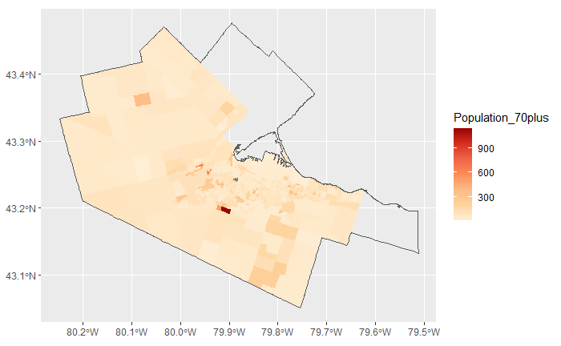

```r
ggplot() +
  geom_sf(data = data_da_2016 %>%
            filter(`Region Name` == "Hamilton"),
          aes(fill = Population_70plus),
          color = NA) +
  geom_sf(data = hamilton_cma,
          fill = NA) +
  scale_fill_distiller(palette = "OrRd",
                       direction = 1)
```

Summary of travel time tables:

```r
summary(ttm_car)
```

```
      UID            OBJECTID   travel_time    Population_55to69  Population_70plus     DAUID               TAZUID         Type               p_car
 Min.   :     1   Min.   : 1   Min.   : 0.00   Min.   :  0.0000   Min.   :  0.0000   Length:3221587     Min.   :5001   Length:3221587     Min.   :0.0000
 1st Qu.: 38321   1st Qu.: 6   1st Qu.:11.00   1st Qu.:  0.4235   1st Qu.:  0.1739   Class :character   1st Qu.:5078   Class :character   1st Qu.:0.9069
 Median : 76582   Median :12   Median :16.00   Median :  0.5172   Median :  0.2715   Mode  :character   Median :5127   Mode  :character   Median :0.9840
 Mean   : 76626   Mean   :12   Mean   :16.44   Mean   :  0.7403   Mean   :  0.4512                      Mean   :5130                      Mean   :0.9270
 3rd Qu.:114350   3rd Qu.:18   3rd Qu.:21.00   3rd Qu.:  0.6560   3rd Qu.:  0.4044                      3rd Qu.:5180                      3rd Qu.:1.0000
 Max.   :155868   Max.   :23   Max.   :61.00   Max.   :429.2167   Max.   :447.9639                      Max.   :5252                      Max.   :1.0000
   p_transit           p_walk
 Min.   :0.00000   Min.   :0.00000
 1st Qu.:0.00000   1st Qu.:0.00000
 Median :0.00000   Median :0.00000
 Mean   :0.05014   Mean   :0.02290
 3rd Qu.:0.06178   3rd Qu.:0.02011
 Max.   :1.00000   Max.   :0.53488
```

```r
summary(ttm_transit)
```

```
      UID            OBJECTID      travel_time     Population_55to69  Population_70plus     DAUID               TAZUID         Type
 Min.   :     1   Min.   : 1.00   Min.   :  0.00   Min.   :  0.0000   Min.   :  0.0000   Length:2663544     Min.   :5001   Length:2663544
 1st Qu.: 38155   1st Qu.: 6.00   1st Qu.: 44.00   1st Qu.:  0.4225   1st Qu.:  0.1737   Class :character   1st Qu.:5082   Class :character
 Median : 75968   Median :12.00   Median : 61.00   Median :  0.5111   Median :  0.2661   Mode  :character   Median :5127   Mode  :character
 Mean   : 76208   Mean   :12.06   Mean   : 67.06   Mean   :  0.7333   Mean   :  0.4527                      Mean   :5130
 3rd Qu.:113655   3rd Qu.:18.00   3rd Qu.: 81.00   3rd Qu.:  0.6361   3rd Qu.:  0.3980                      3rd Qu.:5178
 Max.   :155868   Max.   :23.00   Max.   :179.00   Max.   :204.6316   Max.   :447.9639                      Max.   :5252
     p_car          p_transit           p_walk
 Min.   :0.0000   Min.   :0.00000   Min.   :0.00000
 1st Qu.:0.9029   1st Qu.:0.00000   1st Qu.:0.00000
 Median :0.9826   Median :0.00000   Median :0.00000
 Mean   :0.9228   Mean   :0.05389   Mean   :0.02327
 3rd Qu.:1.0000   3rd Qu.:0.06314   3rd Qu.:0.02410
 Max.   :1.0000   Max.   :1.00000   Max.   :0.53488
```

```r
summary(ttm_walk)
```

```
      UID            OBJECTID      travel_time  Population_55to69  Population_70plus     DAUID               TAZUID         Type               p_car
 Min.   :     1   Min.   : 1.00   Min.   :  0   Min.   :  0.0000   Min.   :  0.0000   Length:1546056     Min.   :5001   Length:1546056     Min.   :0.0000
 1st Qu.: 38662   1st Qu.: 8.00   1st Qu.: 75   1st Qu.:  0.4208   1st Qu.:  0.1770   Class :character   1st Qu.:5084   Class :character   1st Qu.:0.8879
 Median : 75175   Median :13.00   Median :114   Median :  0.5042   Median :  0.2660   Mode  :character   Median :5129   Mode  :character   Median :0.9645
 Mean   : 75685   Mean   :12.66   Mean   :109   Mean   :  0.7443   Mean   :  0.4665                      Mean   :5129                      Mean   :0.9117
 3rd Qu.:111461   3rd Qu.:18.00   3rd Qu.:147   3rd Qu.:  0.6224   3rd Qu.:  0.3924                      3rd Qu.:5174                      3rd Qu.:1.0000
 Max.   :155868   Max.   :23.00   Max.   :180   Max.   :204.6316   Max.   :447.9639                      Max.   :5252                      Max.   :1.0000
   p_transit           p_walk
 Min.   :0.00000   Min.   :0.00000
 1st Qu.:0.00000   1st Qu.:0.00000
 Median :0.01430   Median :0.00000
 Mean   :0.06315   Mean   :0.02511
 3rd Qu.:0.08432   3rd Qu.:0.03206
 Max.   :1.00000   Max.   :0.53488
```

Map proportion of trips by car:

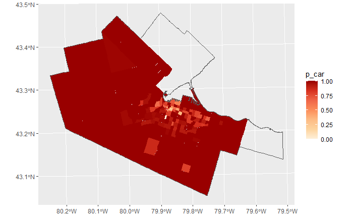

```r
ggplot() +
  geom_sf(data = modes,
          aes(fill = p_car),
          color = NA) +
  geom_sf(data = hamilton_cma,
          fill = NA) +
  scale_fill_distiller(palette = "OrRd",
                       direction = 1)
```

Map proportion of trips by transit:

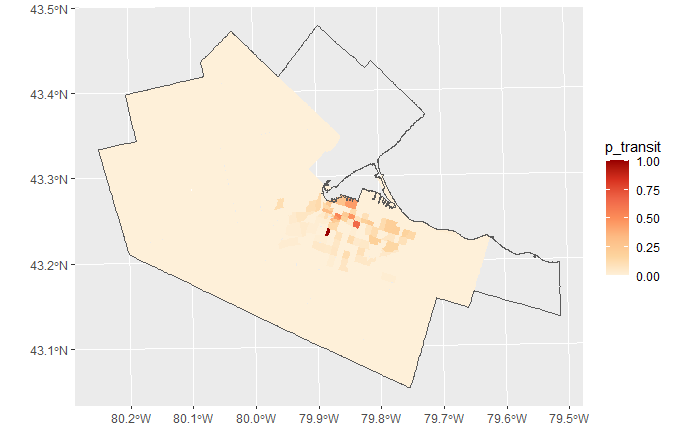

```r
ggplot() +
  geom_sf(data = modes,
          aes(fill = p_transit),
          color = NA) +
  geom_sf(data = hamilton_cma,
          fill = NA) +
  scale_fill_distiller(palette = "OrRd",
                       direction = 1)
```

Map proportion of walking trips:

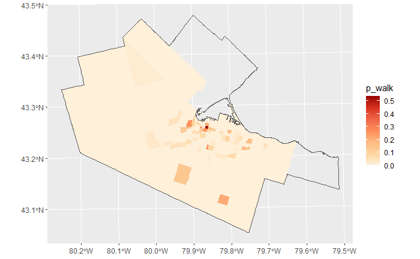

```r
ggplot() +
  geom_sf(data = modes,
          aes(fill = p_walk),
          color = NA) +
  geom_sf(data = hamilton_cma,
          fill = NA) +
  scale_fill_distiller(palette = "OrRd",
                       direction = 1)
```

## Analysis with pilot locations only

Retrieve the minimum travel time from a point to a pharmacy by each mode for people aged 55 to 69 WITH PILOT LOCATIONS ONLY:

```r
min_ttm_car <- ttm_car %>%
  dplyr::filter(Type == "Pilot") %>%
  group_by(UID) %>%
  summarize(travel_time = min(travel_time),
            Population = first(Population_55to69),
            DAUID = first(DAUID),
            TAZUID = first(TAZUID),
            p_car = first(p_car),
            p_transit = first(p_transit),
            p_walk = first(p_walk),
            .groups = "drop")

min_ttm_transit <- ttm_transit %>%
  dplyr::filter(Type == "Pilot") %>%
  group_by(UID) %>%
  summarize(travel_time = min(travel_time),
            Population = first(Population_55to69),
            DAUID = first(DAUID),
            TAZUID = first(TAZUID),
            p_car = first(p_car),
            p_transit = first(p_transit),
            p_walk = first(p_walk),
            .groups = "drop")

min_ttm_walk <- ttm_walk %>%
  dplyr::filter(Type == "Pilot") %>%
  group_by(UID) %>%
  summarize(travel_time = min(travel_time),
            Population = first(Population_55to69),
            DAUID = first(DAUID),
            TAZUID = first(TAZUID),
            p_car = first(p_car),
            p_transit = first(p_transit),
            p_walk = first(p_walk),
            .groups = "drop")
```

Calculate weighted travel time:

```r
min_ttm_car <- min_ttm_car %>%
  mutate(weighted_travel_time = travel_time * p_car)

min_ttm_transit <- min_ttm_transit %>%
  mutate(weighted_travel_time = travel_time * p_transit)

min_ttm_walk <- min_ttm_walk %>%
  mutate(weighted_travel_time = travel_time * p_walk)
```

Bind the three tables:

```r
min_ttm <- rbind(min_ttm_car,
                 min_ttm_transit,
                 min_ttm_walk)
```

Aggregate weighted travel times by mode:

```r
min_ttm <- min_ttm %>%
  group_by(UID) %>%
  summarize(DAUID = first(DAUID),
            TAZUID = first(TAZUID),
            Population = first(Population),
            weighted_travel_time = sum(weighted_travel_time))
```

Calculate person-hours of travel:

```r
min_ttm <- min_ttm %>%
  mutate(weighted_person_hours = Population * weighted_travel_time/60)
```

Summarize by TAZ and join geometry:

```r
min_ttm_taz <- min_ttm %>%
  group_by(TAZUID) %>%
  summarize(weighted_travel_time = mean(weighted_travel_time),
            weighted_person_hours = sum(weighted_person_hours)) %>%
  left_join(modes %>%
              dplyr::select(TAZUID),
            by = "TAZUID") %>%
  st_as_sf()
```

Map weighted travel time:

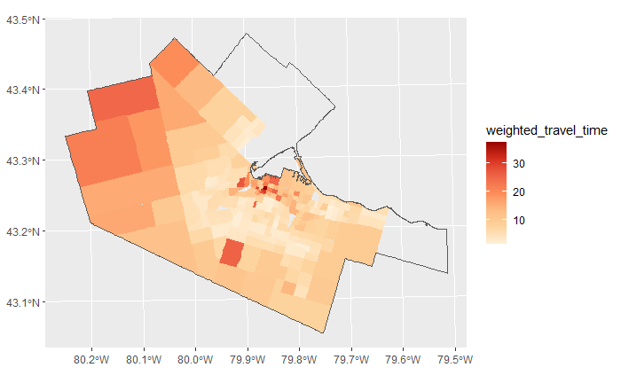

```r
ggplot() +
  geom_sf(data = min_ttm_taz,
          aes(fill = weighted_travel_time),
          color = NA) +
  geom_sf(data = hamilton_cma,
          fill = NA) +
  scale_fill_distiller(palette = "OrRd",
                       direction = 1)
```

Map weighted person-hours of travel:

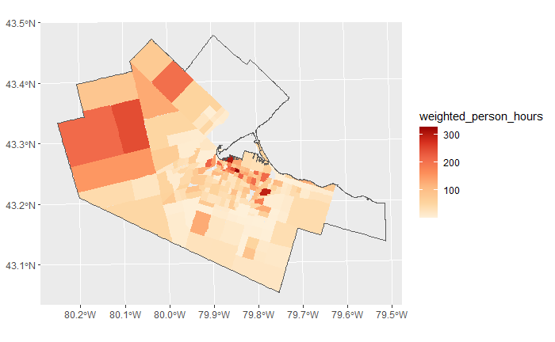

```r
ggplot() +
  geom_sf(data = min_ttm_taz,
          aes(fill = weighted_person_hours),
          color = NA) +
  geom_sf(data = hamilton_cma,
          fill = NA) +
  scale_fill_distiller(palette = "OrRd",
                       direction = 1)
```

Join median household information to table:

```r
min_ttm <- min_ttm %>%
  left_join(data_da_2016 %>%
              st_drop_geometry() %>%
              dplyr::transmute(DAUID = GeoUID,
                               income_quintile),
            by = "DAUID")
```

Distribution of weighted travel time by income:

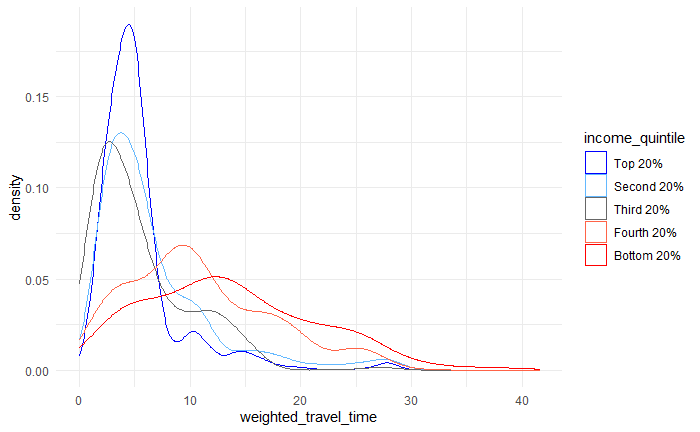

```r
ggplot(data = min_ttm,
       aes(x = weighted_travel_time,
           color= income_quintile)) +
  geom_density(size = 0.5, adjust = 2.5) +
  scale_color_manual(values = c("Top 20%" = "blue",
                                "Second 20%" = "steelblue1",
                                "Third 20%" = "gray40",
                                "Fourth 20%" = "tomato",
                                "Bottom 20%" = "red")) +
  theme_minimal()
```

Total weighted person-hours by income:

```r
min_ttm %>%
  group_by(income_quintile) %>%
  summarize(total_weighted_person_hours = sum(weighted_person_hours),
            total_population = sum(Population),
            .groups = "drop")
```

|  | income_quintile | total_weighted_person_hours | total_population |
| --- | --- | --- | --- |
| 1 | Top 20% | 2243.857 | 23297.31 |
| 2 | Second 20% | 2471.952 | 22356.41 |
| 3 | Third 20% | 1749.497 | 19570.06 |
| 4 | Fourth 20% | 2928.959 | 17729.14 |
| 5 | Bottom 20% | 4068.548 | 19629.95 |

## Analysis with pilot locations + candidates

```r
min_ttm_car_full <- ttm_car %>%
  group_by(UID) %>%
  summarize(travel_time = min(travel_time),
            Population = first(Population_55to69),
            DAUID = first(DAUID),
            TAZUID = first(TAZUID),
            p_car = first(p_car),
            p_transit = first(p_transit),
            p_walk = first(p_walk),
            .groups = "drop")

min_ttm_transit_full <- ttm_transit %>%
  group_by(UID) %>%
  summarize(travel_time = min(travel_time),
            Population = first(Population_55to69),
            DAUID = first(DAUID),
            TAZUID = first(TAZUID),
            p_car = first(p_car),
            p_transit = first(p_transit),
            p_walk = first(p_walk),
            .groups = "drop")

min_ttm_walk_full <- ttm_walk %>%
  group_by(UID) %>%
  summarize(travel_time = min(travel_time),
            Population = first(Population_55to69),
            DAUID = first(DAUID),
            TAZUID = first(TAZUID),
            p_car = first(p_car),
            p_transit = first(p_transit),
            p_walk = first(p_walk),
            .groups = "drop")
```

Calculate weighted travel time:

```r
min_ttm_car_full <- min_ttm_car_full %>%
  mutate(weighted_travel_time = travel_time * p_car)

min_ttm_transit_full <- min_ttm_transit_full %>%
  mutate(weighted_travel_time = travel_time * p_transit)

min_ttm_walk_full <- min_ttm_walk_full %>%
  mutate(weighted_travel_time = travel_time * p_walk)
```

Bind the three tables:

```r
min_ttm_full <- rbind(min_ttm_car_full,
                 min_ttm_transit_full,
                 min_ttm_walk_full)
```

Aggregate weighted travel times by mode:

```r
min_ttm_full <- min_ttm_full %>%
  group_by(UID) %>%
  summarize(DAUID = first(DAUID),
            TAZUID = first(TAZUID),
            Population = first(Population),
            weighted_travel_time = sum(weighted_travel_time))
```

Calculate person-hours of travel:

```r
min_ttm_full <- min_ttm_full %>%
  mutate(weighted_person_hours = Population * weighted_travel_time/60)
```

Summarize by TAZ and join geometry:

```r
min_ttm_taz_full <- min_ttm_full %>%
  group_by(TAZUID) %>%
  summarize(weighted_travel_time = mean(weighted_travel_time),
            weighted_person_hours = sum(weighted_person_hours)) %>%
  left_join(modes %>%
              dplyr::select(TAZUID),
            by = "TAZUID") %>%
  st_as_sf()
```

Map weighted travel time:

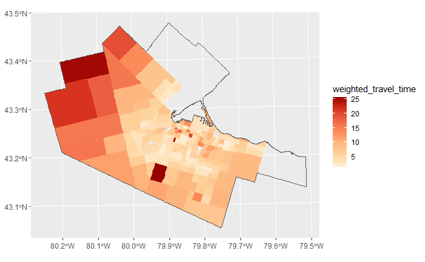

```r
ggplot() +
  geom_sf(data = min_ttm_taz_full,
          aes(fill = weighted_travel_time),
          color = NA) +
  geom_sf(data = hamilton_cma,
          fill = NA) +
  scale_fill_distiller(palette = "OrRd",
                       direction = 1)
```

Map weighted person-hours of travel:

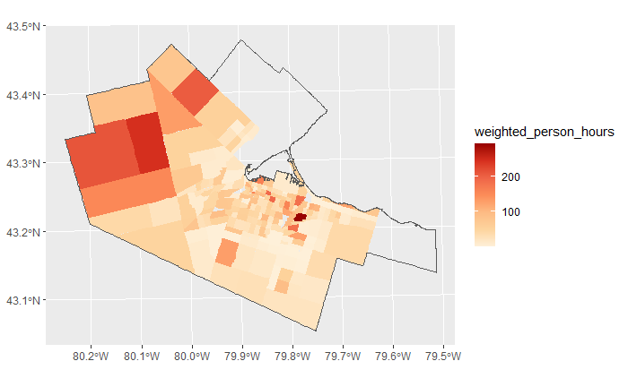

```r
ggplot() +
  geom_sf(data = min_ttm_taz_full,
          aes(fill = weighted_person_hours),
          color = NA) +
  geom_sf(data = hamilton_cma,
          fill = NA) +
  scale_fill_distiller(palette = "OrRd",
                       direction = 1)
```

Join median household information to table:

```r
min_ttm_full <- min_ttm_full %>%
  left_join(data_da_2016 %>%
              st_drop_geometry() %>%
              dplyr::transmute(DAUID = GeoUID,
                               income_quintile),
            by = "DAUID")
```

Distribution of weighted travel time by income:

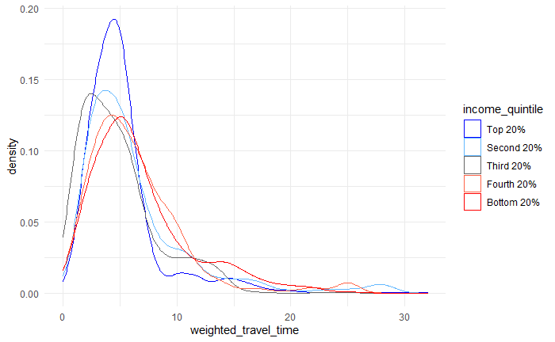

```r
ggplot(data = min_ttm_full,
       aes(x = weighted_travel_time,
           color= income_quintile)) +
  geom_density(size = 0.5, adjust = 2.5) +
  scale_color_manual(values = c("Top 20%" = "blue",
                                "Second 20%" = "steelblue1",
                                "Third 20%" = "gray40",
                                "Fourth 20%" = "tomato",
                                "Bottom 20%" = "red")) +
  theme_minimal()
```

Total weighted person-hours by income:

```r
min_ttm_full %>%
  group_by(income_quintile) %>%
  summarize(total_weighted_person_hours = sum(weighted_person_hours),
            total_population = sum(Population),
            .groups = "drop")
```

|  | income_quintile | total_weighted_person_hours | total_population |
| --- | --- | --- | --- |
| 1 | Top 20% | 2146.558 | 23297.31 |
| 2 | Second 20% | 2351.858 | 22356.41 |
| 3 | Third 20% | 1563.978 | 19570.06 |
| 4 | Fourth 20% | 1950.312 | 17729.14 |
| 5 | Bottom 20% | 2388.422 | 19629.95 |